# zavRad1

36548173 Rossini Marin

2025-03-05

## Učitavanje prvih datasetova

Pred nama se nalazi dataset sa (ne)potpunim podacima svih NBA utakmica u povijesti lige.

```r
nbagames <- read_csv("csv/game.csv")
head(nbagames)
```

```
## # A tibble: 6 × 55
##   season_id team_id_home team_abbreviation_home team_name_home          game_id
##       <dbl>        <dbl> <chr>                  <chr>                   <chr>
## 1     21946   1610610035 HUS                    Toronto Huskies         0024600…
## 2     21946   1610610034 BOM                    St. Louis Bombers       0024600…
## 3     21946   1610610032 PRO                    Providence Steamrollers 0024600…
## 4     21946   1610610025 CHS                    Chicago Stags           0024600…
## 5     21946   1610610028 DEF                    Detroit Falcons         0024600…
## 6     21946   1610610026 CLR                    Cleveland Rebels        0024600…
## # ℹ 50 more variables: game_date <dttm>, matchup_home <chr>, wl_home <chr>,
## #   min <dbl>, fgm_home <dbl>, fga_home <dbl>, fg_pct_home <dbl>,
## #   fg3m_home <dbl>, fg3a_home <dbl>, fg3_pct_home <dbl>, ftm_home <dbl>,
## #   fta_home <dbl>, ft_pct_home <dbl>, oreb_home <dbl>, dreb_home <dbl>,
## #   reb_home <dbl>, ast_home <dbl>, stl_home <dbl>, blk_home <dbl>,
## #   tov_home <dbl>, pf_home <dbl>, pts_home <dbl>, plus_minus_home <dbl>,
## #   video_available_home <dbl>, team_id_away <dbl>, …
```

```r
glimpse(nbagames)
```

```
## Rows: 65,698
## Columns: 55
## $ season_id              <dbl> 21946, 21946, 21946, 21946, 21946, 21946, 21946…
## $ team_id_home           <dbl> 1610610035, 1610610034, 1610610032, 1610610025,…
## $ team_abbreviation_home <chr> "HUS", "BOM", "PRO", "CHS", "DEF", "CLR", "PIT"…
## $ team_name_home         <chr> "Toronto Huskies", "St. Louis Bombers", "Provid…
## $ game_id                <chr> "0024600001", "0024600003", "0024600002", "0024…
## $ game_date              <dttm> 1946-11-01, 1946-11-02, 1946-11-02, 1946-11-02…
## $ matchup_home           <chr> "HUS vs. NYK", "BOM vs. PIT", "PRO vs. BOS", "C…
## $ wl_home                <chr> "L", "W", "W", "W", "L", "W", "L", "L", "L", "W…
## $ min                    <dbl> 0, 0, 0, 0, 0, 0, 0, 0, 0, 0, 0, 0, 0, 0, 0, 0,…
## $ fgm_home               <dbl> 25, 20, 21, 21, 10, 24, 19, 23, 18, 31, 25, 28,…
## $ fga_home               <dbl> NA, 59, NA, NA, NA, NA, NA, NA, NA, NA, 104, NA…
## $ fg_pct_home            <dbl> NA, 0.339, NA, NA, NA, NA, NA, NA, NA, NA, 0.24…
## $ fg3m_home              <dbl> NA, NA, NA, NA, NA, NA, NA, NA, NA, NA, NA, NA,…
```

[output cut: 42 more lines]

```r
summary(nbagames)
```

```
##    season_id      team_id_home       team_abbreviation_home team_name_home
##  Min.   :12005   Min.   :4.500e+01   Length:65698           Length:65698
##  1st Qu.:21981   1st Qu.:1.611e+09   Class :character       Class :character
##  Median :21997   Median :1.611e+09   Mode  :character       Mode  :character
##  Mean   :22949   Mean   :1.610e+09
##  3rd Qu.:22011   3rd Qu.:1.611e+09
##  Max.   :42022   Max.   :1.611e+09
##
##    game_id            game_date                       matchup_home
##  Length:65698       Min.   :1946-11-01 00:00:00.000   Length:65698
##  Class :character   1st Qu.:1982-12-15 06:00:00.000   Class :character
##  Mode  :character   Median :1997-11-06 00:00:00.000   Mode  :character
##                     Mean   :1995-02-15 15:13:23.202
##                     3rd Qu.:2010-04-07 00:00:00.000
##                     Max.   :2023-06-12 00:00:00.000
##
##    wl_home               min         fgm_home        fga_home
##  Length:65698       Min.   :  0   Min.   : 4.00   Min.   :  0.00
##  Class :character   1st Qu.:240   1st Qu.:35.00   1st Qu.: 78.00
##  Mode  :character   Median :240   Median :40.00   Median : 84.00
##                     Mean   :221   Mean   :39.67   Mean   : 83.99
##                     3rd Qu.:240   3rd Qu.:44.00   3rd Qu.: 89.00
##                     Max.   :365   Max.   :84.00   Max.   :240.00
##                                   NA's   :13      NA's   :15447
##   fg_pct_home      fg3m_home        fg3a_home      fg3_pct_home
##  Min.   :0.140   Min.   : 0.000   Min.   : 0.00   Min.   :0.000
##  1st Qu.:0.427   1st Qu.: 2.000   1st Qu.:10.00   1st Qu.:0.261
##  Median :0.467   Median : 5.000   Median :16.00   Median :0.348
##  Mean   :0.467   Mean   : 5.735   Mean   :17.74   Mean   :0.346
##  3rd Qu.:0.506   3rd Qu.: 9.000   3rd Qu.:24.00   3rd Qu.:0.430
##  Max.   :0.697   Max.   :28.000   Max.   :77.00   Max.   :1.000
##  NA's   :15490   NA's   :13218    NA's   :18683   NA's   :19074
##     ftm_home        fta_home      ft_pct_home       oreb_home
##  Min.   : 0.00   Min.   : 0.00   Min.   :0.0000   Min.   : 0.00
##  1st Qu.:16.00   1st Qu.:21.00   1st Qu.:0.6940   1st Qu.: 9.00
##  Median :20.00   Median :27.00   Median :0.7600   Median :12.00
##  Mean   :20.69   Mean   :27.14   Mean   :0.7554   Mean   :12.11
##  3rd Qu.:25.00   3rd Qu.:33.00   3rd Qu.:0.8210   3rd Qu.:15.00
##  Max.   :61.00   Max.   :86.00   Max.   :4.1670   Max.   :44.00
##  NA's   :16      NA's   :3004    NA's   :3009     NA's   :18936
```

[output cut: 65 more lines]

```
##  Min.   : 0.0    Min.   :  0.0   Min.   : 19   Min.   :-73.000
##  1st Qu.:12.0    1st Qu.: 20.0   1st Qu.: 92   1st Qu.:-12.000
##  Median :15.0    Median : 23.0   Median :101   Median : -4.000
##  Mean   :15.2    Mean   : 23.1   Mean   :101   Mean   : -3.628
##  3rd Qu.:18.0    3rd Qu.: 26.0   3rd Qu.:110   3rd Qu.:  5.000
##  Max.   :40.0    Max.   :115.0   Max.   :196   Max.   : 68.000
##  NA's   :18685   NA's   :2851
##  video_available_away season_type
##  Min.   :0.0000       Length:65698
##  1st Qu.:0.0000       Class :character
##  Median :0.0000       Mode  :character
##  Mean   :0.2013
##  3rd Qu.:0.0000
##  Max.   :1.0000
##
```

S obzirom da nas zanimaju potpuniji podaci, koji su dostupni od sezone 1985/1986, ranije podatke ćemo ukloniti.

```r
nbagamesClear <- nbagames %>% filter(complete.cases(nbagames))
```

## Podjela na regularnu sezonu i playoff

Uklanjamo nepotrebne stupce i dijelimo dataset na regularnu sezonu i playoff. S obzirom na veću količinu podataka, mi ćemo promatrati podatke iz regularne sezone.

```r
interval <- dmy("1.7.1985") %--% today()
nbagamesClear %>% filter(game_date %within% interval) -> nbaK
nbaK <- nbaK %>% select(-min, -video_available_home, -video_available_away)

nbaK %>% filter(season_id > 30000) -> nbaPlayoffs
nbaK %>% filter(season_id < 30000 & season_id > 20000) -> nbaRS
head(nbaRS)
```

```
## # A tibble: 6 × 52
##   season_id team_id_home team_abbreviation_home team_name_home         game_id
##       <dbl>        <dbl> <chr>                  <chr>                  <chr>
## 1     21985   1610612737 ATL                    Atlanta Hawks          00285000…
## 2     21985   1610612765 DET                    Detroit Pistons        00285000…
## 3     21985   1610612744 GOS                    Golden State Warriors  00285000…
## 4     21985   1610612751 NJN                    New Jersey Nets        00285000…
## 5     21985   1610612741 CHI                    Chicago Bulls          00285000…
## 6     21985   1610612757 POR                    Portland Trail Blazers 00285000…
## # ℹ 47 more variables: game_date <dttm>, matchup_home <chr>, wl_home <chr>,
## #   fgm_home <dbl>, fga_home <dbl>, fg_pct_home <dbl>, fg3m_home <dbl>,
## #   fg3a_home <dbl>, fg3_pct_home <dbl>, ftm_home <dbl>, fta_home <dbl>,
## #   ft_pct_home <dbl>, oreb_home <dbl>, dreb_home <dbl>, reb_home <dbl>,
## #   ast_home <dbl>, stl_home <dbl>, blk_home <dbl>, tov_home <dbl>,
## #   pf_home <dbl>, pts_home <dbl>, plus_minus_home <dbl>, team_id_away <dbl>,
## #   team_abbreviation_away <chr>, team_name_away <chr>, matchup_away <chr>, …
```

## Dodavanje stupca gamesPlayed, numberOfWins, WinPCT

U ovom dijeli dodajem tri dodatna stupca koja će biti korisna u kasnijoj analizi:  
1) gamesPlayedHome/Away - broj odigranih utakmica u tekućoj sezoni

2. numberOfWinsHome/Away - broj pobjeda u tekućoj sezoni
3. Home/AwayTeamWinPCT - postotak pobjeda momčadi u tekućoj sezoni, najbolji parametar za praćenje uspješnosti momčadi (jer obično ekipe nemaju uvijek jednak broj odigranih utakmica)

```r
nbaRS %>% mutate(RowID = row_number()) %>%
  group_by(team_id_home, season_id) %>%
  arrange(game_date) %>%
  mutate(winHome = ifelse(wl_home == "W", 1, 0)) %>%
  mutate(numberofWinsHome = lag(cumsum(winHome), default = 0),
         CumHomeGames = row_number() - 1,
         HomeTeamPCT = ifelse(CumHomeGames > 0, numberofWinsHome / CumHomeGames, NA)) %>%
  ungroup() %>%
  group_by(team_id_away, season_id) %>%
  arrange(game_date) %>%
  mutate(winAway = ifelse(wl_away == "W", 1, 0)) %>%
  mutate(numberofWinsAway = lag(cumsum(winAway), default = 0),
         CumAwayGames = row_number() - 1,
         AwayTeamPCT = ifelse(CumAwayGames > 0, numberofWinsAway / CumAwayGames, NA)) %>%
  ungroup() %>%
  arrange(RowID) %>%
  select(-RowID, -winHome, -CumHomeGames, -winAway, -CumAwayGames)
```

```
## # A tibble: 41,853 × 56
##    season_id team_id_home team_abbreviation_home team_name_home         game_id
##        <dbl>        <dbl> <chr>                  <chr>                  <chr>
##  1     21985   1610612737 ATL                    Atlanta Hawks          0028500…
##  2     21985   1610612765 DET                    Detroit Pistons        0028500…
##  3     21985   1610612744 GOS                    Golden State Warriors  0028500…
##  4     21985   1610612751 NJN                    New Jersey Nets        0028500…
##  5     21985   1610612741 CHI                    Chicago Bulls          0028500…
##  6     21985   1610612757 POR                    Portland Trail Blazers 0028500…
##  7     21985   1610612739 CLE                    Cleveland Cavaliers    0028500…
##  8     21985   1610612752 NYK                    New York Knicks        0028500…
##  9     21985   1610612741 CHI                    Chicago Bulls          0028500…
## 10     21985   1610612742 DAL                    Dallas Mavericks       0028500…
## # ℹ 41,843 more rows
## # ℹ 51 more variables: game_date <dttm>, matchup_home <chr>, wl_home <chr>,
## #   fgm_home <dbl>, fga_home <dbl>, fg_pct_home <dbl>, fg3m_home <dbl>,
## #   fg3a_home <dbl>, fg3_pct_home <dbl>, ftm_home <dbl>, fta_home <dbl>,
## #   ft_pct_home <dbl>, oreb_home <dbl>, dreb_home <dbl>, reb_home <dbl>,
## #   ast_home <dbl>, stl_home <dbl>, blk_home <dbl>, tov_home <dbl>,
## #   pf_home <dbl>, pts_home <dbl>, plus_minus_home <dbl>, team_id_away <dbl>, …
```

```r
pomocna_tablica <- nbaRS %>%
  mutate(
    team_id = team_id_home,
    opp_id = team_id_away,
    fgm = fgm_home,
    fga = fga_home,
    fg_pct = fg_pct_home,
    fg3m = fg3m_home,
    fg3a = fg3a_home,
    fg3_pct = fg3_pct_home,
    ftm = ftm_home,
    fta = fta_home,
    ft_pct = ft_pct_home,
    oreb = oreb_home,
    dreb = dreb_home,
    reb = reb_home,
    ast = ast_home,
    stl = stl_home,
    blk = blk_home,
    tov = tov_home,
    pf = pf_home,
    ptsScored = pts_home,
    ptsConceded = pts_away,
    plus_minus = plus_minus_home,
    wl = wl_home
  ) %>%
  select(game_date, season_id, team_id, opp_id, fgm, fga, fg_pct, fg3m, fg3a, fg3_pct, ftm, fta, ft_pct, oreb, dreb, reb, ast, stl, blk, tov, pf, ptsScored, ptsConceded, plus_minus, wl) %>%
  bind_rows(
    nbaRS %>%
      mutate(
        team_id = team_id_away,
        opp_id = team_id_home,
        fgm = fgm_away,
        fga = fga_away,
        fg_pct = fg_pct_away,
        fg3m = fg3m_away,
        fg3a = fg3a_away,
        fg3_pct = fg3_pct_away,
        ftm = ftm_away,
        fta = fta_away,
        ft_pct = ft_pct_away,
        oreb = oreb_away,
        dreb = dreb_away,
        reb = reb_away,
        ast = ast_away,
        stl = stl_away,
        blk = blk_away,
        tov = tov_away,
        pf = pf_away,
        ptsScored = pts_away,
        ptsConceded = pts_home,
        plus_minus = plus_minus_away,
        wl = wl_away
      ) %>%
      select(game_date, season_id, team_id, opp_id, fgm, fga, fg_pct, fg3m, fg3a, fg3_pct, ftm, fta, ft_pct, oreb, dreb, reb, ast, stl, blk, tov, pf, ptsScored, ptsConceded, plus_minus, wl)
  )
```

```r
pomocna_tablica %>% mutate(RowID = row_number()) %>%
  group_by(team_id, season_id) %>%
  arrange(game_date) %>%
  mutate(win = ifelse(wl == "W", 1, 0),
         loss = ifelse(wl == "L", 1, 0)) %>%
  mutate(numberofWins = lag(cumsum(win), default = 0),
         numberofLost = lag(cumsum(loss), default = 0),
         CumGames = row_number() - 1,
         TeamWinPCT = ifelse(CumGames > 0, round(numberofWins / CumGames, 3), NA),

         fgmTotal = lag(cumsum(fgm), default = 0),
         fgaTotal = lag(cumsum(fga), default = 0),
         fgPCT = ifelse(CumGames > 0, round(fgmTotal / fgaTotal, 3), NA), #bitno
         fg3mTotal = lag(cumsum(fg3m), default = 0),
         fg3aTotal = lag(cumsum(fg3a), default = 0),
         fg3PCT = ifelse(CumGames > 0, round(fg3mTotal / fg3aTotal, 3), NA), #bitno
         ftmTotal = lag(cumsum(ftm), default = 0),
         ftaTotal = lag(cumsum(fta), default = 0),
         ftPCT = ifelse(CumGames > 0, round(ftmTotal / ftaTotal, 3), NA), #bitno

         orebTotal = lag(cumsum(oreb), default = 0),
         orebAvg = ifelse(CumGames > 0, round(orebTotal / CumGames, 3), NA), #bitno
         drebTotal = lag(cumsum(dreb), default = 0),
         drebAvg = ifelse(CumGames > 0, round(drebTotal / CumGames, 3), NA), #bitno
         rebTotal = lag(cumsum(reb), default = 0),
         rebAvg = ifelse(CumGames > 0, round(rebTotal / CumGames, 3), NA), #bitno
         astTotal = lag(cumsum(ast), default = 0),
         astAvg = ifelse(CumGames > 0, round(astTotal / CumGames, 3), NA), #bitno
         stlTotal = lag(cumsum(stl), default = 0),
         stlAvg = ifelse(CumGames > 0, round(stlTotal / CumGames, 3), NA), #bitno
         blkTotal = lag(cumsum(blk), default = 0),
         blkAvg = ifelse(CumGames > 0, round(blkTotal / CumGames, 3), NA), #bitno
         tovTotal = lag(cumsum(tov), default = 0),
         tovAvg = ifelse(CumGames > 0, round(tovTotal / CumGames, 3), NA), #bitno
         pfTotal = lag(cumsum(pf), default = 0),
         pfAvg = ifelse(CumGames > 0, round(pfTotal / CumGames, 3), NA), #bitno
         ptsScoredTotal = lag(cumsum(ptsScored), default = 0),
         ptsScoredAvg = ifelse(CumGames > 0, round(ptsScoredTotal / CumGames, 3), NA), #bitno
         ptsConcededTotal = lag(cumsum(ptsConceded), default = 0),
         ptsConcededAvg = ifelse(CumGames > 0, round(ptsConcededTotal / CumGames, 3), NA), #bitno
         plus_minusTotal = lag(cumsum(plus_minus), default = 0),
         plus_minusAvg = ifelse(CumGames > 0, round(plus_minusTotal / CumGames, 3), NA), #bitno
         ) %>%
  ungroup() %>% arrange(RowID) %>%
  select(-RowID, -win, -loss, -fgmTotal, -fgaTotal, -fg3mTotal, -fg3aTotal, -ftmTotal, -ftaTotal, -orebTotal, -drebTotal, -rebTotal, -astTotal, -stlTotal, -blkTotal, -tovTotal, -pfTotal, -ptsScoredTotal, -plus_minusTotal) -> pomocna_tablica
```

```r
nbaRS2 <- nbaRS %>%
  left_join(
    pomocna_tablica %>%
      select(game_date, season_id, team_id, CumGames, numberofWins, numberofLost, TeamWinPCT, fgPCT, fg3PCT, ftPCT, orebAvg, drebAvg, rebAvg, astAvg, stlAvg, blkAvg, tovAvg, pfAvg, ptsScoredAvg, ptsConcededAvg, plus_minusAvg) %>%
      rename(
        gamesPlayedHome = CumGames,
        numberofWinsHome = numberofWins,
        numberofLostHome = numberofLost,
        homeTeamWinPCT = TeamWinPCT,
        homeFGPCT = fgPCT,
        homeFG3PCT = fg3PCT,
        homeFTPCT = ftPCT,
        oRebAvgHome = orebAvg,
        dRebAvgHome = drebAvg,
        rebAvgHome = rebAvg,
        astAvgHome = astAvg,
        stlAvgHome = stlAvg,
        blkAvgHome = blkAvg,
        tovAvgHome = tovAvg,
        pfAvgHome = pfAvg,
        ptsScoredAvgHome = ptsScoredAvg,
        ptsConcededAvgHome = ptsConcededAvg,
        plus_minusAvgHome = plus_minusAvg
      ),
    by = c("game_date", "season_id", "team_id_home" = "team_id")
  ) %>%
  left_join(
    pomocna_tablica %>%
      select(game_date, season_id, team_id, CumGames, numberofWins, numberofLost, TeamWinPCT, fgPCT, fg3PCT, ftPCT, orebAvg, drebAvg, rebAvg, astAvg, stlAvg, blkAvg, tovAvg, pfAvg, ptsScoredAvg, ptsConcededAvg, plus_minusAvg) %>%
      rename(
        gamesPlayedAway = CumGames,
        numberofWinsAway = numberofWins,
        numberofLostAway = numberofLost,
        awayTeamWinPCT = TeamWinPCT,
        awayFGPCT = fgPCT,
        awayFG3PCT = fg3PCT,
        awayFTPCT = ftPCT,
        oRebAvgAway = orebAvg,
        dRebAvgAway = drebAvg,
        rebAvgAway = rebAvg,
        astAvgAway = astAvg,
        stlAvgAway = stlAvg,
        blkAvgAway = blkAvg,
        tovAvgAway = tovAvg,
        pfAvgAway = pfAvg,
        ptsScoredAvgAway = ptsScoredAvg,
        ptsConcededAvgAway = ptsConcededAvg,
        plus_minusAvgAway = plus_minusAvg
      ),
    by = c("game_date", "season_id", "team_id_away" = "team_id")
  )

tail(nbaRS2, 1000)
```

```
## # A tibble: 1,000 × 88
##    season_id team_id_home team_abbreviation_home team_name_home         game_id
##        <dbl>        <dbl> <chr>                  <chr>                  <chr>
##  1     22022   1610612744 GSW                    Golden State Warriors  0022200…
##  2     22022   1610612747 LAL                    Los Angeles Lakers     0022200…
##  3     22022   1610612764 WAS                    Washington Wizards     0022200…
##  4     22022   1610612739 CLE                    Cleveland Cavaliers    0022200…
##  5     22022   1610612754 IND                    Indiana Pacers         0022200…
##  6     22022   1610612737 ATL                    Atlanta Hawks          0022200…
##  7     22022   1610612755 PHI                    Philadelphia 76ers     0022200…
##  8     22022   1610612757 POR                    Portland Trail Blazers 0022200…
##  9     22022   1610612746 LAC                    LA Clippers            0022200…
## 10     22022   1610612751 BKN                    Brooklyn Nets          0022200…
## # ℹ 990 more rows
## # ℹ 83 more variables: game_date <dttm>, matchup_home <chr>, wl_home <chr>,
## #   fgm_home <dbl>, fga_home <dbl>, fg_pct_home <dbl>, fg3m_home <dbl>,
## #   fg3a_home <dbl>, fg3_pct_home <dbl>, ftm_home <dbl>, fta_home <dbl>,
## #   ft_pct_home <dbl>, oreb_home <dbl>, dreb_home <dbl>, reb_home <dbl>,
## #   ast_home <dbl>, stl_home <dbl>, blk_home <dbl>, tov_home <dbl>,
## #   pf_home <dbl>, pts_home <dbl>, plus_minus_home <dbl>, team_id_away <dbl>, …
```

## Međusobni omjer

Dodajem nove stupce za broj pobjeda svake ekipe u 10 posljednih međusobnih utakmica

Za to je koristan stupac matchup_home (ili away) koji je id za međusobne utakmice dviju ekipa

Problem: kratice pojedinih ekipa su se mijenjale kroz povijest te to prvo moramo riješiti.

```r
nbaRS2$matchup_home <- gsub("SAN", "SAS", nbaRS2$matchup_home)
nbaRS2$matchup_home <- gsub("CHH", "CHA", nbaRS2$matchup_home)
nbaRS2$matchup_home <- gsub("NOH", "NOP", nbaRS2$matchup_home)
nbaRS2$matchup_home <- gsub("NOK", "NOP", nbaRS2$matchup_home)
nbaRS2$matchup_home <- gsub("PHL", "PHI", nbaRS2$matchup_home)
nbaRS2$matchup_home <- gsub("UTH", "UTA", nbaRS2$matchup_home)
nbaRS2$matchup_home <- gsub("GOS", "GSW", nbaRS2$matchup_home)
nbaRS2$matchup_home <- gsub("NJN", "BKN", nbaRS2$matchup_home)
nbaRS2$matchup_home <- gsub("VAN", "MEM", nbaRS2$matchup_home)
#nbaRS2 %>% filter(matchup_home == "LAL vs. SAS")
#nbaRS2 %>% select(matchup_home) %>% group_by(matchup_home) %>% distinct() %>% arrange(matchup_home)
```

Sad kad je to riješeno, napravimo ta dva stupca.

```r
nbaRS2 %>% group_by(matchup_home) %>%
  mutate(
    homeH2HWins = lag(slide_dbl(ifelse(wl_home == "W", 1, 0), sum, .before = 9, .complete = FALSE), default = 0),
    awayH2HWins = lag(slide_dbl(ifelse(wl_home == "L", 1, 0), sum, .before = 9, .complete = FALSE), default = 0)
  ) %>%
  ungroup() -> nbaRS3
```

### Najčešći matchupi

```r
nbaRS3 %>% count(matchup_home) %>% arrange(desc(n))
```

```
## # A tibble: 928 × 2
##    matchup_home     n
##    <chr>        <int>
##  1 DAL vs. SAS     81
##  2 NYK vs. PHI     81
##  3 BOS vs. BKN     80
##  4 CHI vs. MIL     80
##  5 CLE vs. IND     80
##  6 HOU vs. DAL     80
##  7 CHI vs. DET     79
##  8 CLE vs. DET     79
##  9 DAL vs. HOU     79
## 10 DET vs. CHI     79
## # ℹ 918 more rows
```

#### Koliko često pobjeđuje momčad koja pogodi barem 25 trica kod kuće?

Odgovor: gotovo uvijek, samo jednom je takva momčad izgubila (LA Clippersi protiv Sacramento Kingsa).

```r
nbaRS3 %>% filter(fg3m_home >= 25) %>% select(game_date, matchup_home, wl_home, fg3m_home)
```

```
## # A tibble: 24 × 4
##    game_date           matchup_home wl_home fg3m_home
##    <dttm>              <chr>        <chr>       <dbl>
##  1 2018-12-19 00:00:00 HOU vs. WAS  W              26
##  2 2019-01-19 00:00:00 HOU vs. LAL  W              25
##  3 2019-04-07 00:00:00 HOU vs. PHX  W              27
##  4 2019-11-30 00:00:00 HOU vs. ATL  W              25
##  5 2020-02-08 00:00:00 MIN vs. LAC  W              26
##  6 2020-08-01 00:00:00 LAC vs. NOP  W              25
##  7 2021-02-10 00:00:00 CHI vs. NOP  W              25
##  8 2021-02-12 00:00:00 DAL vs. NOP  W              25
##  9 2021-02-22 00:00:00 UTA vs. CHA  W              28
## 10 2021-04-03 00:00:00 UTA vs. ORL  W              26
## # ℹ 14 more rows
```

## Dodan stupac ishoda utakmice (winner)

Ovo je stupac koji je cilj naše prediktivne analize.

```r
nbaRS3 %>% mutate(winner = ifelse(wl_home == "W", "H", "A")) -> nbaRS3
```

## Kreiranje data framea s konačnim podacima svake ekipe na kraju sezone

Kako bismo donositi bolje zaključke u eksploratornoj analizi, napravit ćemo data frame u kojemu ćemo imati konačne statistike svake momčadi na kraju svake regularne sezone za koje imamo dostupne podatke.

```r
nbaRS4 <- nbaRS3 %>% filter(complete.cases(nbaRS3))

nbaRS5 <- nbaRS4 %>%
  mutate(
    team_id = team_id_home,
    team_name = team_name_home,
    opp_id = team_id_away,
    opp_name = team_name_away,
    gamesPlayed = gamesPlayedHome,
    numberofWins = numberofWinsHome,
    numberofLost = numberofLostHome,
    teamWinPCT = homeTeamWinPCT,
    FGPCT = homeFGPCT,
    FG3PCT = homeFG3PCT,
    FTPCT = homeFTPCT,
    oRebAvg = oRebAvgHome,
    dRebAvg = dRebAvgHome,
    rebAvg = rebAvgHome,
    astAvg = astAvgHome,
    stlAvg = stlAvgHome,
    blkAvg = blkAvgHome,
    tovAvg = tovAvgHome,
    pfAvg = pfAvgHome,
    ptsScoredAvg = ptsScoredAvgHome,
    ptsConcededAvg = ptsConcededAvgHome,
    plus_minusAvg = plus_minusAvgHome,
    wl = wl_home
  ) %>%
  select(game_date, season_id, team_id, team_name, opp_id, opp_name, game_id, matchup_home, gamesPlayed, numberofWins, numberofLost, teamWinPCT, FGPCT, FG3PCT, FTPCT, oRebAvg, dRebAvg, rebAvg, astAvg, stlAvg, blkAvg, tovAvg, pfAvg, ptsScoredAvg, ptsConcededAvg, plus_minusAvg, wl) %>%
  bind_rows(
    nbaRS4 %>%
      mutate(
        team_id = team_id_away,
        team_name = team_name_away,
        opp_id = team_id_home,
        opp_name = team_name_home,
        gamesPlayed = gamesPlayedAway,
        numberofWins = numberofWinsAway,
        numberofLost = numberofLostAway,
        teamWinPCT = awayTeamWinPCT,
        FGPCT = awayFGPCT,
        FG3PCT = awayFG3PCT,
        FTPCT = awayFTPCT,
        oRebAvg = oRebAvgAway,
        dRebAvg = dRebAvgAway,
        rebAvg = rebAvgAway,
        astAvg = astAvgAway,
        stlAvg = stlAvgAway,
        blkAvg = blkAvgAway,
        tovAvg = tovAvgAway,
        pfAvg = pfAvgAway,
        ptsScoredAvg = ptsScoredAvgAway,
        ptsConcededAvg = ptsConcededAvgAway,
        plus_minusAvg = plus_minusAvgAway,
        wl = wl_away
      ) %>%
      select(game_date, season_id, team_id, team_name, opp_id, opp_name, game_id, matchup_home, gamesPlayed, numberofWins, numberofLost, teamWinPCT, FGPCT, FG3PCT, FTPCT, oRebAvg, dRebAvg, rebAvg, astAvg, stlAvg, blkAvg, tovAvg, pfAvg, ptsScoredAvg, ptsConcededAvg, plus_minusAvg, wl)
  )
```

```r
nbaRSFinal <- nbaRS5 %>% filter(gamesPlayed == 81 | (gamesPlayed == 71 & season_id == 22020) | (gamesPlayed == 65 & season_id == 22011)) %>% arrange(season_id, desc(numberofWins))

nbaRSFinal %>%
  mutate(
    gamesPlayed = gamesPlayed + 1,
    numberofWins = ifelse(wl == "W", numberofWins + 1, numberofWins),
    numberofLost = ifelse(wl == "W", numberofLost, numberofLost + 1)
  ) -> nbaRSFinal

nbaRSFinal <- nbaRSFinal %>% select(-game_date, -opp_id, -opp_name, -game_id, -matchup_home, -wl)

head(nbaRSFinal)
```

```
## # A tibble: 6 × 21
##   season_id   team_id team_name gamesPlayed numberofWins numberofLost teamWinPCT
##       <dbl>     <dbl> <chr>           <dbl>        <dbl>        <dbl>      <dbl>
## 1     21987    1.61e9 Los Ange…          82           62           20      0.753
## 2     21987    1.61e9 Dallas M…          82           53           29      0.642
## 3     21988    1.61e9 Chicago …          82           47           35      0.58
## 4     21988    1.61e9 Sacramen…          82           27           55      0.333
## 5     21988    1.61e9 New Jers…          82           26           56      0.321
## 6     21989    1.61e9 Chicago …          82           55           27      0.679
## # ℹ 14 more variables: FGPCT <dbl>, FG3PCT <dbl>, FTPCT <dbl>, oRebAvg <dbl>,
## #   dRebAvg <dbl>, rebAvg <dbl>, astAvg <dbl>, stlAvg <dbl>, blkAvg <dbl>,
## #   tovAvg <dbl>, pfAvg <dbl>, ptsScoredAvg <dbl>, ptsConcededAvg <dbl>,
## #   plus_minusAvg <dbl>
```

```r
nbaRSFinal %>% count(season_id)
```

```
## # A tibble: 33 × 2
##    season_id     n
##        <dbl> <int>
##  1     21987     2
##  2     21988     3
##  3     21989     4
##  4     21990     7
##  5     21991    14
##  6     21992    20
##  7     21993    20
##  8     21994    27
##  9     21995    29
## 10     21996    29
## # ℹ 23 more rows
```

Sad kad smo uspjeli napraviti data frame koji sadrži konačne statistike momčadi na kraju sezone, možemo krenuti u vizualizaciju podataka.

## Vizualizacija podataka

Istražujemo kako koja statistika utječe na konačni ishod utakmice.

### Povezanost broja skokova i asistencija s ishodom utakmice

```r
reb_melted <- melt(nbaRS4, id.vars = "winner", measure.vars = c("reb_home", "reb_away"),
                     variable.name = "Team", value.name = "reb")

ggplot(reb_melted, aes(x = winner, y = reb, fill = Team)) +
  geom_boxplot() +
  labs(title = "Prosječan broj skokova prema ishodu utakmice",
       x = "Ishod utakmice",
       y = "Prosječan broj skokova",
       fill = "Tim") +
  scale_fill_manual(labels = c("Domaći", "Gosti"), values = c("dodgerblue", "firebrick1")) +
  theme_minimal() -> g1
```

```r
ast_melted <- melt(nbaRS4, id.vars = "winner", measure.vars = c("ast_home", "ast_away"),
                     variable.name = "Team", value.name = "ast")

ggplot(ast_melted, aes(x = winner, y = ast, fill = Team)) +
  geom_boxplot() +
  labs(title = "Broj asistencija prema ishodu utakmice",
       x = "Ishod utakmice",
       y = "Broj asistencija",
       fill = "Tim") +
  scale_fill_manual(labels = c("Domaći", "Gosti"), values = c("dodgerblue", "firebrick1")) +
  theme_minimal() -> g2
```

### Povezanost postotka šuta za 3 i ishoda utakmice

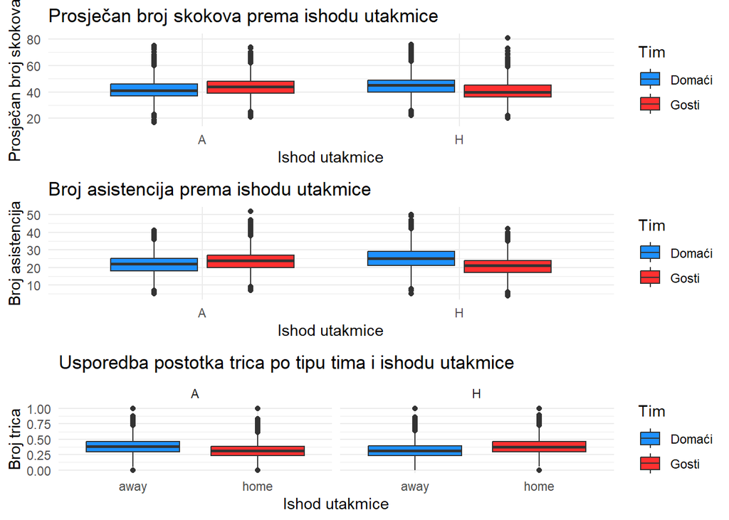

```r
three_point_data <- nbaRS4 %>%
  select(winner, fg3m_home, fg3_pct_home, fg3m_away, fg3_pct_away) %>%
  pivot_longer(
    cols = -winner,
    names_to = c(".value", "team_type"),
    names_pattern = "(fg3m|fg3_pct)_(home|away)"
  )

ggplot(three_point_data, aes(x = team_type, y = fg3_pct, fill = team_type)) +
  geom_boxplot() +
  facet_wrap(~winner) +
  labs(title = "Usporedba postotka trica po tipu tima i ishodu utakmice",
       x = "Ishod utakmice",
       y = "Broj trica",
       fill = "Tim") +
  scale_fill_manual(labels = c("Domaći", "Gosti"), values = c("dodgerblue", "firebrick1")) +
  theme_minimal() -> g3

grid.arrange(g1, g2, g3)
```

```r
ggplot(nbaRSFinal, aes(x = FG3PCT, y = teamWinPCT)) +
  geom_point(color = "dodgerblue") +
  geom_smooth(method = "lm", se = FALSE) +
  scale_y_continuous(
    labels = percent_format(accuracy = 1, scale = 100)) +
  scale_x_continuous(
    labels = percent_format(accuracy = 1, scale = 100)) +
  labs(title = "Povezanost postotka šuta za 3 s postotkom pobjeda",
       x = "Postotak trica",
       y = "Postotak pobjeda") +
  theme_minimal() -> g4
```

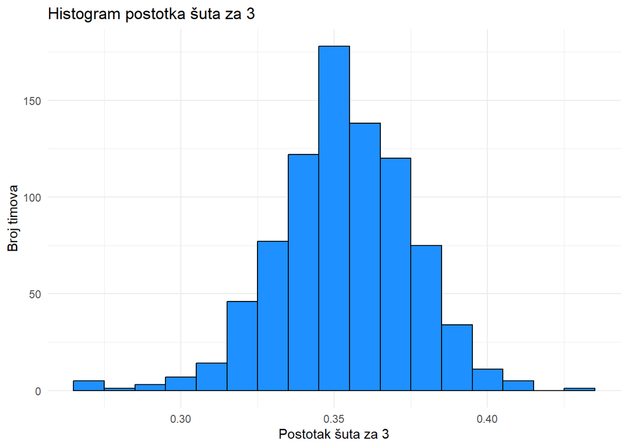

```r
ggplot(nbaRSFinal, aes(x = FG3PCT)) +
  geom_histogram(binwidth = 0.01, fill = "dodgerblue", color = "black") +
  labs(x = "Postotak šuta za 3", y = "Broj timova", title = "Histogram postotka šuta za 3") +
  theme_minimal()
```

Što bolje momčad šutira, to je vjerojatnije da će ta momčad biti bolja. Uočavamo da na kraju histogram postotka šuta za tri poena vuče čak na normalnu razdiobu.

### Korelacija postotka pobjeda i broja postignutih koševa

```r
ggplot(nbaRSFinal, aes(x = ptsScoredAvg, y = teamWinPCT)) +
  geom_point(color = "dodgerblue") +
  geom_smooth(method = "lm", se = FALSE) +
  scale_y_continuous(
    labels = percent_format(accuracy = 1, scale = 100)) +
  labs(title = "Povezanost prosječnog broja koševa s postotkom pobjeda",
       x = "Prosječan broj postignutih koševa",
       y = "Postotak pobjeda") +
  theme_minimal() -> g1
```

### Korelacija postotka pobjeda i broja primljenih koševa

```r
ggplot(nbaRSFinal, aes(x = ptsConcededAvg, y = teamWinPCT)) +
  geom_point(color = "dodgerblue") +
  geom_smooth(method = "lm", se = FALSE) +
  scale_y_continuous(
    labels = percent_format(accuracy = 1, scale = 100)) +
  labs(title = "Povezanost prosječnog broja primljenih koševa s postotkom pobjeda",
       x = "Prosječan broj primljenih koševa",
       y = "Postotak pobjeda") +
  theme_minimal() -> g2
```

Napad dobija utakmice, a obrana prvenstva. Ova posljednja dva grafa to potvrđuju. Vidimo da je korelacija između postotka pobjeda i primljenih poena jača nego ona između postotka pobjeda i postignutih poena.

### Korelacija postotka pobjeda i plus/minus statistike

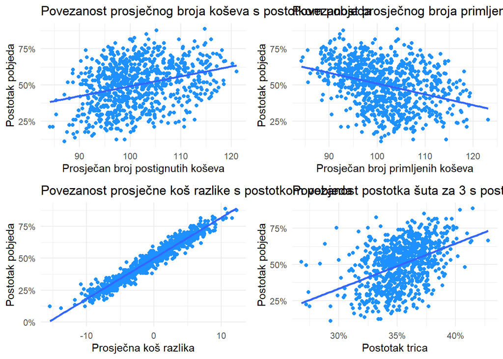

```r
ggplot(nbaRSFinal, aes(x = plus_minusAvg, y = teamWinPCT)) +
  geom_point(color = "dodgerblue") +
  geom_smooth(method = "lm", se = FALSE) +
  scale_y_continuous(
    labels = percent_format(accuracy = 1, scale = 100)) +
  labs(title = "Povezanost prosječne koš razlike s postotkom pobjeda",
       x = "Prosječna koš razlika",
       y = "Postotak pobjeda") +
  theme_minimal() -> g3

grid.arrange(g1, g2, g3, g4, nrow = 2, ncol = 2)
```

Momčadi koje imaju oboje, naravno, postižu najbolje rezultate. Tako da, potpuno očekivano, korelacija između plus/minus statistike (prosječna koš razlika po utakmici) i postotka pobjede je velika.

### Graf postignutih i primljenih koševa ovisno o postotku pobjeda

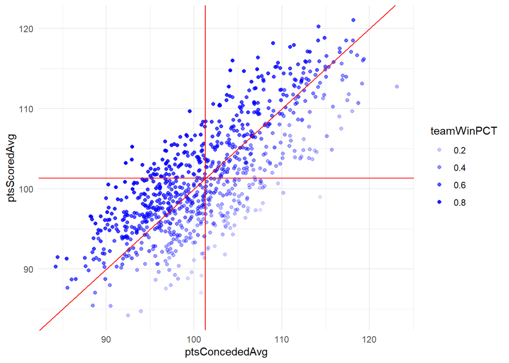

```r
ptsScoredMean = mean(nbaRSFinal$ptsScoredAvg)
ptsConcededMean = mean(nbaRSFinal$ptsConcededAvg)

ggplot(nbaRSFinal, aes(x = ptsConcededAvg, y = ptsScoredAvg, alpha = teamWinPCT)) +
  geom_point(color = "blue") +
  geom_hline(aes(yintercept = ptsConcededMean), color = "red") +
  geom_vline(aes(xintercept = ptsScoredMean), color = "red") +
  geom_abline(aes(intercept = 0, slope = 1), color = "red") +
  theme_minimal()
```

### Graf broja asistencija o postotku pobjeda

```r
ggplot(nbaRSFinal, aes(x = astAvg, y = teamWinPCT)) +
  geom_point(color = "dodgerblue") +
  geom_smooth(method = "lm", se = FALSE) +
  theme_minimal() -> g1
```

### Graf ovisnosti broja izgubljenih lopti o postotku pobjeda

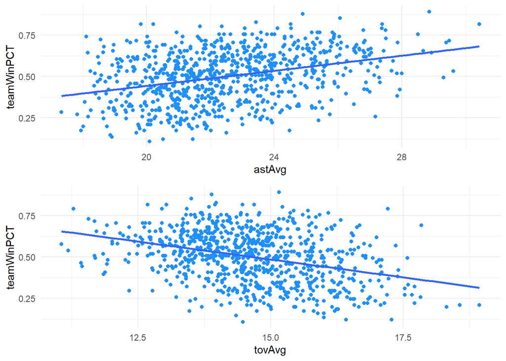

```r
ggplot(nbaRSFinal, aes(x = tovAvg, y = teamWinPCT)) +
  geom_point(color = "dodgerblue") +
  geom_smooth(method = "lm", se = FALSE) +
  theme_minimal() -> g2

grid.arrange(g1, g2)
```

## Modeli za predviđanje

### Bez prvih 5

```r
nbaRS0 <- nbaRS4 %>% filter(gamesPlayedHome > 5) %>% select(team_name_home, team_name_away, game_date, matchup_home, homeTeamWinPCT, homeFGPCT, homeFG3PCT, homeFTPCT, oRebAvgHome, dRebAvgHome, rebAvgHome, astAvgHome, stlAvgHome, blkAvgHome, tovAvgHome, pfAvgHome, plus_minusAvgHome, awayTeamWinPCT, awayFGPCT, awayFG3PCT, awayFTPCT, oRebAvgAway, dRebAvgAway, rebAvgAway, astAvgAway, stlAvgAway, blkAvgAway, tovAvgAway, pfAvgAway, plus_minusAvgAway, homeH2HWins, awayH2HWins, winner)
nbaRS0
```

```
## # A tibble: 38,648 × 33
##    team_name_home team_name_away game_date           matchup_home homeTeamWinPCT
##    <chr>          <chr>          <dttm>              <chr>                 <dbl>
##  1 Milwaukee Buc… San Antonio S… 1985-11-05 00:00:00 MIL vs. SAS           0.667
##  2 Los Angeles L… Denver Nuggets 1985-11-08 00:00:00 LAL vs. DEN           0.833
##  3 Portland Trai… Seattle Super… 1985-11-08 00:00:00 POR vs. SEA           0.714
##  4 Dallas Maveri… Houston Rocke… 1985-11-09 00:00:00 DAL vs. HOU           0.333
##  5 New Jersey Ne… Milwaukee Buc… 1985-11-09 00:00:00 BKN vs. MIL           0.667
##  6 Detroit Pisto… Boston Celtics 1985-11-09 00:00:00 DET vs. BOS           0.714
##  7 Portland Trai… Cleveland Cav… 1985-11-10 00:00:00 POR vs. CLE           0.75
##  8 Golden State … Sacramento Ki… 1985-11-10 00:00:00 GSW vs. SAC           0.333
##  9 San Antonio S… New Jersey Ne… 1985-11-11 00:00:00 SAS vs. BKN           0.5
## 10 Detroit Pisto… Washington Bu… 1985-11-12 00:00:00 DET vs. WAS           0.625
## # ℹ 38,638 more rows
## # ℹ 28 more variables: homeFGPCT <dbl>, homeFG3PCT <dbl>, homeFTPCT <dbl>,
## #   oRebAvgHome <dbl>, dRebAvgHome <dbl>, rebAvgHome <dbl>, astAvgHome <dbl>,
## #   stlAvgHome <dbl>, blkAvgHome <dbl>, tovAvgHome <dbl>, pfAvgHome <dbl>,
## #   plus_minusAvgHome <dbl>, awayTeamWinPCT <dbl>, awayFGPCT <dbl>,
## #   awayFG3PCT <dbl>, awayFTPCT <dbl>, oRebAvgAway <dbl>, dRebAvgAway <dbl>,
## #   rebAvgAway <dbl>, astAvgAway <dbl>, stlAvgAway <dbl>, blkAvgAway <dbl>, …
```

### Bez prvih 10

```r
nbaRS10 <- nbaRS4 %>% filter(gamesPlayedHome > 10) %>% select(team_name_home, team_name_away, game_date, matchup_home, homeTeamWinPCT, homeFGPCT, homeFG3PCT, homeFTPCT, oRebAvgHome, dRebAvgHome, rebAvgHome, astAvgHome, stlAvgHome, blkAvgHome, tovAvgHome, pfAvgHome, plus_minusAvgHome, awayTeamWinPCT, awayFGPCT, awayFG3PCT, awayFTPCT, oRebAvgAway, dRebAvgAway, rebAvgAway, astAvgAway, stlAvgAway, blkAvgAway, tovAvgAway, pfAvgAway, plus_minusAvgAway, homeH2HWins, awayH2HWins, winner)
nbaRS10
```

```
## # A tibble: 36,028 × 33
##    team_name_home team_name_away game_date           matchup_home homeTeamWinPCT
##    <chr>          <chr>          <dttm>              <chr>                 <dbl>
##  1 Milwaukee Buc… Detroit Pisto… 1985-11-13 00:00:00 MIL vs. DET           0.636
##  2 Milwaukee Buc… Chicago Bulls  1985-11-15 00:00:00 MIL vs. CHI           0.667
##  3 Portland Trai… New Jersey Ne… 1985-11-19 00:00:00 POR vs. BKN           0.636
##  4 Chicago Bulls  Indiana Pacers 1985-11-19 00:00:00 CHI vs. IND           0.364
##  5 Dallas Maveri… Phoenix Suns   1985-11-19 00:00:00 DAL vs. PHX           0.364
##  6 Phoenix Suns   San Antonio S… 1985-11-20 00:00:00 PHX vs. SAS           0.091
##  7 Denver Nuggets Los Angeles L… 1985-11-21 00:00:00 DEN vs. LAL           0.818
##  8 San Antonio S… Indiana Pacers 1985-11-22 00:00:00 SAS vs. IND           0.455
##  9 Detroit Pisto… Golden State … 1985-11-22 00:00:00 DET vs. GSW           0.545
## 10 Cleveland Cav… Utah Jazz      1985-11-22 00:00:00 CLE vs. UTA           0.364
## # ℹ 36,018 more rows
## # ℹ 28 more variables: homeFGPCT <dbl>, homeFG3PCT <dbl>, homeFTPCT <dbl>,
## #   oRebAvgHome <dbl>, dRebAvgHome <dbl>, rebAvgHome <dbl>, astAvgHome <dbl>,
## #   stlAvgHome <dbl>, blkAvgHome <dbl>, tovAvgHome <dbl>, pfAvgHome <dbl>,
## #   plus_minusAvgHome <dbl>, awayTeamWinPCT <dbl>, awayFGPCT <dbl>,
## #   awayFG3PCT <dbl>, awayFTPCT <dbl>, oRebAvgAway <dbl>, dRebAvgAway <dbl>,
## #   rebAvgAway <dbl>, astAvgAway <dbl>, stlAvgAway <dbl>, blkAvgAway <dbl>, …
```

```r
nbaRS0 %>% count(winner)
```

```
## # A tibble: 2 × 2
##   winner     n
##   <chr>  <int>
## 1 A      15363
## 2 H      23285
```

### Normalizacija podataka

```r
nbaRSNorm <- lapply(nbaRS0, function(x) {
  if(is.numeric(x)) (x - mean(x)) / sd(x)
  else x
}) %>% as.data.frame
```

```r
nbaRSNorm1 <- lapply(nbaRS10, function(x) {
  if(is.numeric(x)) (x - mean(x)) / sd(x)
  else x
}) %>% as.data.frame
```

### Podjela na trening i test podatke

#### Bez prvih 5

```r
trainingSet <- nbaRSNorm[1:27053,c(6:32)]
testSet <- nbaRSNorm[27054:38648,c(6:32)]

trainingOutcomes <- nbaRSNorm[1:27053,33]
testOutcomes <- nbaRSNorm[27054:38648,33]

trainingOutcomes <- as.factor(trainingOutcomes)
testOutcomes <- as.factor(testOutcomes)
```

#### Bez prvih 10

```r
trainingSet <- nbaRSNorm1[1:25219,c(6:32)]
testSet <- nbaRSNorm1[25220:36028,c(6:32)]

trainingOutcomes <- nbaRSNorm1[1:25219,33]
testOutcomes <- nbaRSNorm1[25220:36028,33]

trainingOutcomes <- as.factor(trainingOutcomes)
testOutcomes <- as.factor(testOutcomes)
```

### Random forest

```r
set.seed(3000)
model <- randomForest(x = trainingSet, y = trainingOutcomes, ntree = 1000, mtry = 3, classwt = c(A = 1, H = 2), keep.forest = TRUE)
predictions <- predict(model, newdata = testSet)

accuracy <- mean(predictions == testOutcomes)
print(paste("Accuracy:", accuracy))
```

```
## [1] "Accuracy: 0.648441113886576"
```

```r
cat("------------------------------------------------------------\n")
conf_matrix <- table(Predicted = predictions, Actual = testOutcomes)
print(conf_matrix)
```

```
##          Actual
## Predicted    A    H
##         A 2079 1259
##         H 2541 4930
```

### Support Vector Machine

```r
svm_model <- svm(x = trainingSet, y = trainingOutcomes,
                 kernel = "radial")
predictions <- predict(svm_model, newdata = testSet)

accuracy <- mean(predictions == testOutcomes)
print(paste("Accuracy:", accuracy))
```

```
## [1] "Accuracy: 0.637246738828754"
```

```r
cat("------------------------------------------------------------\n")
conf_matrix <- table(Predicted = predictions, Actual = testOutcomes)
print(conf_matrix)
```

```
##          Actual
## Predicted    A    H
##         A 1633  934
##         H 2987 5255
```

### Logistička regresija

```r
model <- multinom(trainingOutcomes ~ ., data = trainingSet)
predictions <- predict(model, newdata = testSet)

accuracy <- mean(predictions == testOutcomes)
print(paste("Accuracy:", accuracy))
```

```
## [1] "Accuracy: 0.650013877324452"
```

```r
cat("------------------------------------------------------------\n")
conf_matrix <- table(Predicted = predictions, Actual = testOutcomes)
print(conf_matrix)
```

```
##          Actual
## Predicted    A    H
##         A 1931 1094
##         H 2689 5095
```